# 1c96fee4-af67-4c6f-bc39-6dcac175a197

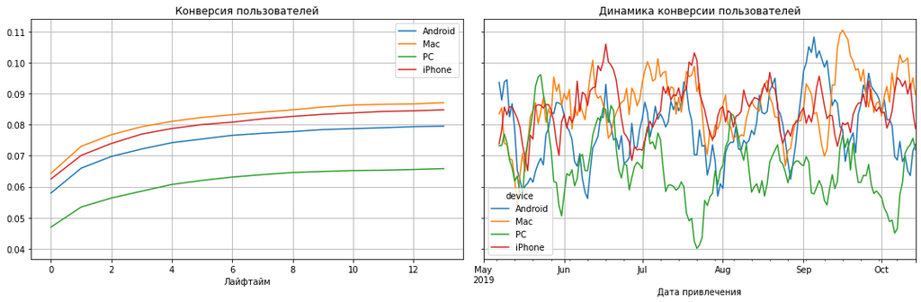

```python
conversion_raw, conversion_grouped, conversion_history = get_conversion(
    profiles, orders, max_date, horizon_days, dimensions=dimensions)
plot_conversion(conversion_grouped, conversion_history, horizon_days)
```

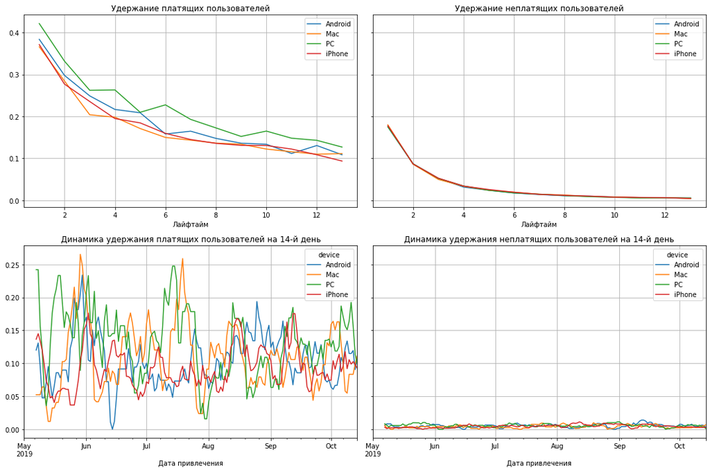

```python
retention_raw, retention_grouped, retention_history = get_retention(
    profiles, visits, max_date, horizon_days, dimensions = dimensions)
plot_retention(retention_grouped, retention_history, horizon_days)
```

В графиках разбивки по устройствам, видим, что порог окупаемости был достигнут при использовании РС. При этом на графике динамики ROI пользователей мы наблюдаем какую то сезонную зависимость. Падение окупаемости началось с окончанием лета.

LTV так же демонстрирует стабильный рост, как и при конверсии пользователей.

И удержание, в общем смысле, не показало ничего нового. Только что клиенты, использующие РС удерживаются лучше, чем остальные, что может помочь для обдумывания новых стратегий.

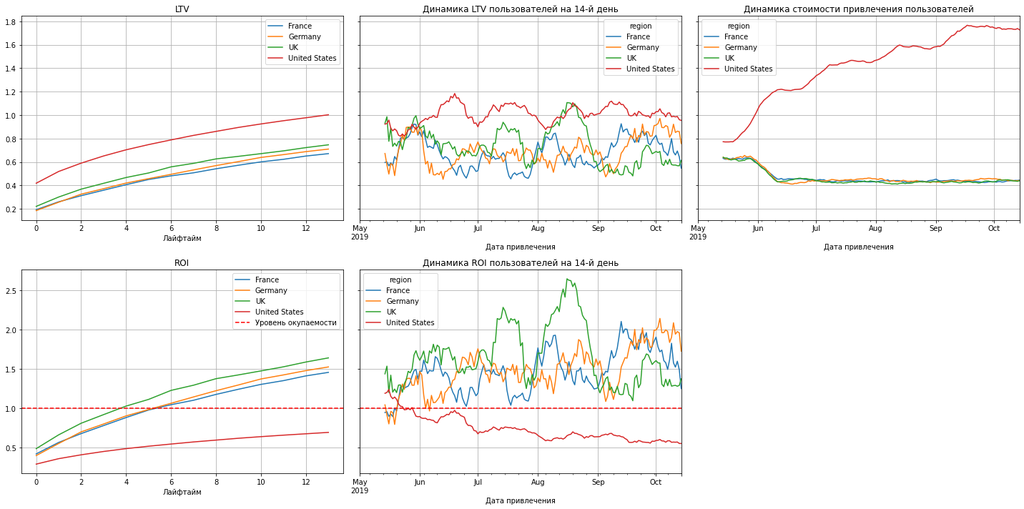

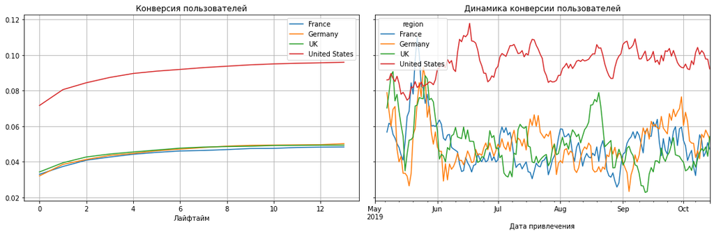

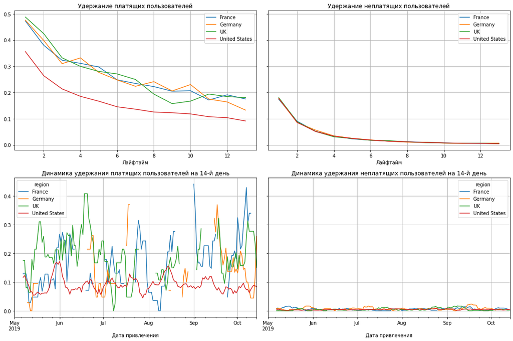

```python
dimensions = ['region']
ltv_raw, ltv_grouped, ltv_history, roi_grouped, roi_history = get_ltv(
    profiles, orders, max_date, horizon_days, dimensions=dimensions)
plot_ltv_roi(ltv_grouped, ltv_history, roi_grouped, roi_history, horizon_days, window=14)
conversion_raw, conversion_grouped, conversion_history = get_conversion(
    profiles, orders, max_date, horizon_days, dimensions=dimensions)
plot_conversion(conversion_grouped, conversion_history, horizon_days)
retention_raw, retention_grouped, retention_history = get_retention(
    profiles, visits, max_date, horizon_days, dimensions = dimensions)
plot_retention(retention_grouped, retention_history, horizon_days)
```

В разбивке по странам мы увидели, что все рекмалные компании окупаются, кроме США. А как ранее мы исследовали, самый высокий поток и посетителей и покупателей именно из США. При этом все финансовые усилия оказываются тщетными. И при этом мы видим только рост и рост вложений в рекламную компанию в стране.

Удержание покупателей при этом самое низкое опять же в США.

Все эти факторы нам указывают на провальное проведение рекламной компании в США и на "бездарную" трату бюджета.

(# а можно предположить, что это происки врагов и сливание денежных средств зарубеж, в частности, прям вот нами и открыт канал "слива". Это мы 14 дней только посмотрели, а каковы маштабы в общем?! на фоне увлекательной информационной войны рф-сша можно прям задуматься о легальности деятельности развлекательного приложения и таких маштабных затрат именно в США или! это сотрудник-маркетолог-одиночка договорился с компанией , это мы ниже сейчас узнаем какой, и за ретро-бонус (старинное понятие, пришедшее нам из забытых времен без демократии и правильного экономического курса) вот-вот и оформит свое светлое и мирное существование... хм)

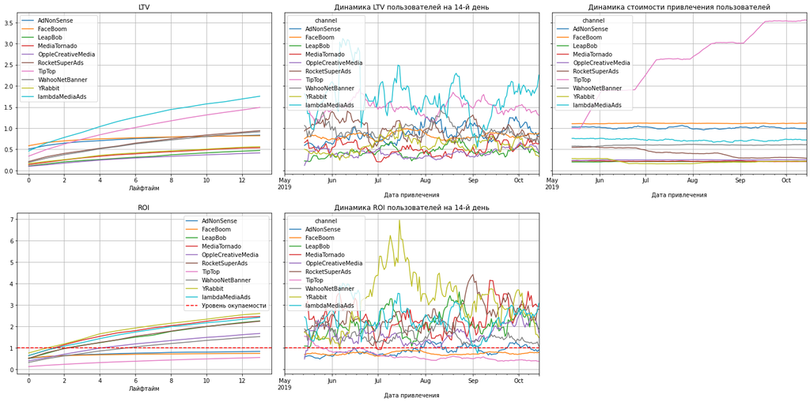

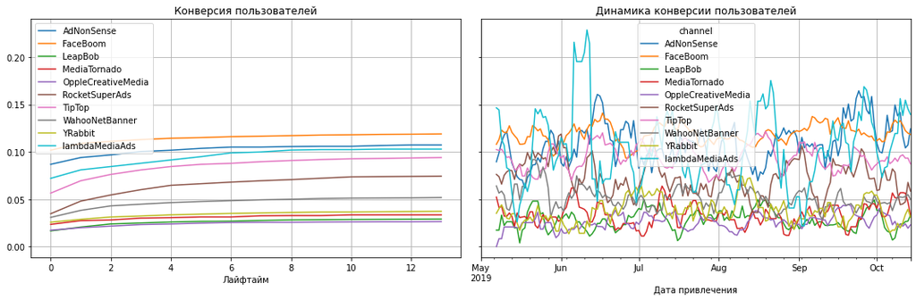

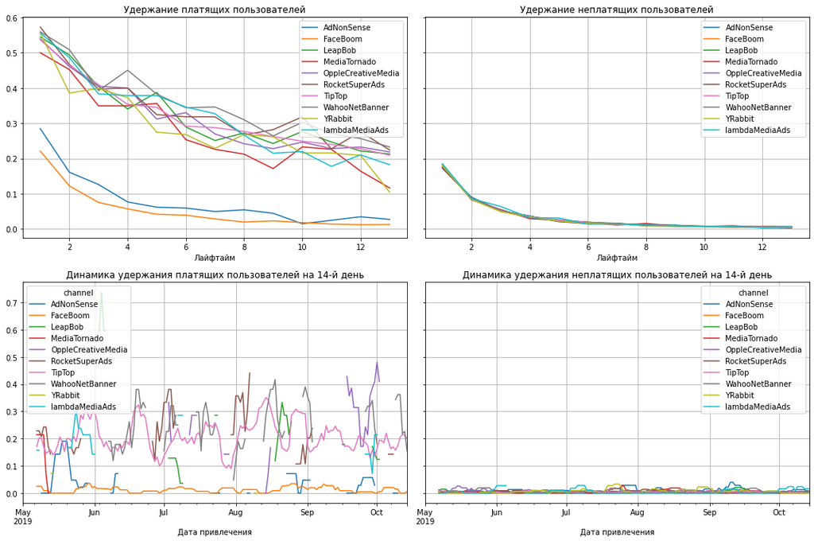

```python
dimensions = ['channel']
ltv_raw, ltv_grouped, ltv_history, roi_grouped, roi_history = get_ltv(
    profiles, orders, max_date, horizon_days, dimensions=dimensions)
plot_ltv_roi(ltv_grouped, ltv_history, roi_grouped, roi_history, horizon_days, window=14)
conversion_raw, conversion_grouped, conversion_history = get_conversion(
    profiles, orders, max_date, horizon_days, dimensions=dimensions)
plot_conversion(conversion_grouped, conversion_history, horizon_days)
retention_raw, retention_grouped, retention_history = get_retention(
    profiles, visits, max_date, horizon_days, dimensions = dimensions)
plot_retention(retention_grouped, retention_history, horizon_days)
```

И на данном этапе исследования мы видим, что лидеры-каналы, FaceBoom и TipTop, оказываются не достигают порога окупаемости.

AdNonSense и FaceBoom не в силах не то что удержать покупателя, этой тенденции у нас нет ни у какого из канала, но и не в состоянии "попытаться".

ОТВЕТЫ НА ВОПРОСЫ:

- реклама, направленная на привлечение пользователей в целом, не окупается
- негативное влиение мы обнаружили на устройствах iPhone и МАС из США и рекламные каналы TipTop, FaceBoom и AdNonSense
- если не рассматривать целенаправленные действия на провал рекламной компании в этих направлениях, то повлиять может ограниченность доступа и плохая работа приложений, убирающих эти ограничения

### Напишите выводы

- Выделите причины неэффективности привлечения пользователей.
- Сформулируйте рекомендации для отдела маркетинга.

Итак, в ходе исследования данных о пользователях, привлечённых с 1 мая по 27 октября 2019 года, компании развлекательного приложения Procrastinate Pro+, мы изучили лог сервера с данными об их посещениях, выгрузку их покупок за этот период, рекламные расходы.

Определили период привлечения пользователей. Первая покупка произошла 01.05.2019, а последняя - 27.10.2019.

Определили лидирующую страну, из которой пользователи приходят в проложение. Ею является США. Более 100 тыс пользователей. При этом с большим отрывом идут Франция и Великобритания, 17450 и 17575 посетителей, соответственно, и Германия - 14981 посетителей. При этом, в долевом решении, США, бесспорно, так и остается в лидерах и доля платящих покупателей соствляет 6,90%. А вот "серебро" достается Германии - 4.11% доля платящих покупателей, против французов и великобританцев.

Определили, что 54479 клиентов используют iPhone, 35032 - Android, 30455 и 30042 - Мас и РС, соответственно.

Изучили рекламные источники и определили "тройку" каналов-лидеров (organic (56439 клиентов), FaceBoom (29144 клиентов) и TipTop (19561 клиент)) Они же являются и лидерами, приведшими больше всего платящих клиентов.

Посчитали общую сумму расходов на маркетинг, которая составила 105497.0 .

Определили, что больше всего средств вложено в рекламный источник TipTop (54751.00), далее 32445.00 потрачено на FaceBoom. Именно эти два рекламных канала заняли 82,65% от общей суммы расходов на маркетинг.

Посчитали САС для всего проекта (0.7557). Основные затраты пришлись на TipTop, FaceBoom, AdNonSense.

Предположили, что стоило бы обратить внимание и сократить высокие расходы на каналы TipTop, FaceBoom, AdNonSense, переключив внимание на развитие каналов с минимальными расходами на привлечение клиентов.

Показали , что реклама, направленная на привлечение пользователей в целом, не окупается.

Негативное влиение мы обнаружили на устройствах iPhone и МАС из США и рекламные каналы TipTop, FaceBoom и AdNonSense.

Можно рекомендовать прежде всего снизить высокие затраты на провальную рекламную компанию.

Рассмотреть варианты развития направлений со достигнутыми порогами окупаемости. Уделить внимание другим странам. Пересмотреть политику в области продвижения рекламы по другим каналам